# USL - In-Class Lab Exercise (Week-2-Part-2) - Questions

|  | Inclass - Lab (Week-2-Part-2) |
| --- | --- |

### About the dataset (Rain prediction data)

The dataset consists of various factors like temperature, humidity, a wind speed that are important in predicting the rainfall in the Indian subcontinent.

**Temperature_min**: Minimum temperature for the day

**Temperature_max**: Maximum temperature for the day

**WindSpeedAt3am**: Today's speed of the wind at 3 am

**WindSpeedAt10am**: Today's speed of the wind at 10 am

**WindSpeedAt6pm**: Today's speed of the wind at 6 pm

**HumidityLevelAt10am**: Today's humidity level at 10 am

**HumidityAt6pm**: Today's humidity level at 6 pm

**PressureAt10am**: Today's atmospheric pressure at 10 am

**PressureAt6pm**: Today's atmospheric pressure at 6 pm

**TemperatureAt10am**: Today's temperature at 10 am

**TemperatureAt6pm**: Today's temperature at 6 pm

**WillRainTomorrow?**: Will there be rain tomorrow? (Yes or No) (target/dependent variable)

Use different dimension reduction techniques to transform the dataset into the lower dimension.

## Table of Content

1. **Exploratory Data Analysis**
2. **Principal Component Analysis (PCA)**

**Import the required libraries**

```python
import numpy as np
import matplotlib.pyplot as plt
import pandas as pd
```

#### Load the csv file

```python
df_rain = pd.read_csv('F:/Games & Jars/NewErp/Inclass/Ind_Climate_RainPred.csv')
df_rain
```

|  | Temperature_min | Temperature_max | WindSpeedAt3am | WindSpeedAt10am | WindSpeedAt6pm | HumidityLevelAt10am | HumidityAt6pm | PressureAt10am | PressureAt6pm | TemperatureAt10am | TemperatureAt6pm | WillRainTomorrow? |
| --- | --- | --- | --- | --- | --- | --- | --- | --- | --- | --- | --- | --- |
| 0 | 20.3 | 30.7 | 32 | 6 | 17 | 110 | 72 | 1025.2 | 1015.4 | 26.6 | 40.4 | No |
| 1 | 30.0 | 33.3 | 33 | 10 | 20 | 70 | 35 | 1032.6 | 1035.4 | 26.6 | 39.3 | No |
| 2 | 23.5 | 26.9 | 24 | 14 | 20 | 98 | 63 | 1025.5 | 1026.0 | 29.8 | 34.6 | Yes |
| 3 | 25.5 | 26.9 | 45 | 20 | 30 | 82 | 59 | 1019.3 | 1016.9 | 24.2 | 30.8 | No |
| 4 | 33.5 | 39.3 | 33 | 4 | 12 | 94 | 49 | 1027.3 | 1022.2 | 33.6 | 43.6 | No |
| ... | ... | ... | ... | ... | ... | ... | ... | ... | ... | ... | ... | ... |
| 10459 | 30.7 | 44.1 | 52 | 19 | 36 | 55 | 57 | 1017.4 | 1017.6 | 43.7 | 42.8 | Yes |
| 10460 | 27.5 | 38.1 | 57 | 7 | 25 | 82 | 53 | 1022.8 | 1017.5 | 40.8 | 43.2 | Yes |
| 10461 | 25.9 | 25.7 | 37 | 18 | 16 | 75 | 83 | 1025.7 | 1027.5 | 32.8 | 31.2 | Yes |
| 10462 | 21.4 | 35.5 | 46 | 11 | 21 | 91 | 63 | 1017.9 | 1015.3 | 30.6 | 39.5 | No |
| 10463 | 24.7 | 34.0 | 49 | 12 | 19 | 77 | 60 | 1027.0 | 1024.3 | 33.9 | 45.8 | Yes |

10464 rows × 12 columns

### Let's begin with some hands-on practice exercises

## 1. Exploratory Data Analysis

|  | **1. Check the datatype of all the variables in the dataset. If the datatype is not as per the definition, do the needful.** |
| --- | --- |

```python
df_rain.dtypes
```

```
Temperature_min        float64
Temperature_max        float64
WindSpeedAt3am           int64
WindSpeedAt10am          int64
WindSpeedAt6pm           int64
HumidityLevelAt10am      int64
HumidityAt6pm            int64
PressureAt10am         float64
PressureAt6pm          float64
TemperatureAt10am      float64
TemperatureAt6pm       float64
WillRainTomorrow?       object
dtype: object
```

|  | **2. Check the statistical summary of all the numerical variables.** |
| --- | --- |

```python
df_rain.describe()
```

|  | Temperature_min | Temperature_max | WindSpeedAt3am | WindSpeedAt10am | WindSpeedAt6pm | HumidityLevelAt10am | HumidityAt6pm | PressureAt10am | PressureAt6pm | TemperatureAt10am | TemperatureAt6pm |
| --- | --- | --- | --- | --- | --- | --- | --- | --- | --- | --- | --- |
| count | 10464.000000 | 10464.000000 | 10464.000000 | 10464.000000 | 10464.000000 | 10464.000000 | 10464.000000 | 10464.000000 | 10464.000000 | 10464.000000 | 10464.000000 |
| mean | 26.308964 | 30.309939 | 41.391820 | 15.379683 | 20.394209 | 82.210627 | 60.992928 | 1023.362481 | 1020.702332 | 30.713083 | 36.218626 |
| std | 6.843041 | 7.424327 | 14.437279 | 7.449217 | 7.847386 | 18.557838 | 22.737736 | 7.536385 | 7.433202 | 6.752840 | 7.723442 |
| min | 7.200000 | 13.200000 | 9.000000 | 2.000000 | 2.000000 | 11.000000 | 4.000000 | 993.700000 | 991.900000 | 10.300000 | 16.700000 |
| 25% | 21.300000 | 24.600000 | 31.000000 | 10.000000 | 15.000000 | 70.000000 | 44.000000 | 1018.400000 | 1015.600000 | 25.800000 | 30.600000 |
| 50% | 26.200000 | 29.500000 | 39.000000 | 14.000000 | 20.000000 | 85.000000 | 59.000000 | 1023.400000 | 1020.700000 | 30.800000 | 35.600000 |
| 75% | 31.500000 | 35.600000 | 49.000000 | 20.000000 | 25.000000 | 98.000000 | 77.000000 | 1028.600000 | 1025.700000 | 35.400000 | 41.400000 |
| max | 47.300000 | 55.800000 | 131.000000 | 58.000000 | 63.000000 | 110.000000 | 110.000000 | 1048.900000 | 1046.400000 | 56.300000 | 63.300000 |

|  | **3. Is the target variable highly imbalanced?** |
| --- | --- |

```python
df_rain.columns
```

```
Index(['Temperature_min', 'Temperature_max', 'WindSpeedAt3am',
       'WindSpeedAt10am', 'WindSpeedAt6pm', 'HumidityLevelAt10am',
       'HumidityAt6pm', 'PressureAt10am', 'PressureAt6pm', 'TemperatureAt10am',
       'TemperatureAt6pm', 'WillRainTomorrow?'],
      dtype='object')
```

```python
df_rain['WillRainTomorrow?'].value_counts() / len(df_rain) * 100

# Not Imbalanced
# Balanced
```

```
No     52.217125
Yes    47.782875
Name: WillRainTomorrow?, dtype: float64
```

|  | **4. Check if any missing values are present in the data. If yes, do the needful.** |
| --- | --- |

```python
df_rain.isnull().sum()
```

```
Temperature_min        0
Temperature_max        0
WindSpeedAt3am         0
WindSpeedAt10am        0
WindSpeedAt6pm         0
HumidityLevelAt10am    0
HumidityAt6pm          0
PressureAt10am         0
PressureAt6pm          0
TemperatureAt10am      0
TemperatureAt6pm       0
WillRainTomorrow?      0
dtype: int64
```

|  | **5. Visualize the distribution of all the independent variables and identify the type of skewness.** |
| --- | --- |

```
Temperature_min        0.006720
Temperature_max        0.361414
WindSpeedAt3am         0.965806
WindSpeedAt10am        0.681830
WindSpeedAt6pm         0.625044
HumidityLevelAt10am   -0.636941
HumidityAt6pm          0.187420
PressureAt10am        -0.050507
PressureAt6pm          0.004457
TemperatureAt10am      0.075801
TemperatureAt6pm       0.312913
dtype: float64
```

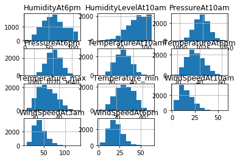

```python
df_rain.hist()
df_rain.skew()
```

|  | **6. Transform the independent variables such that each variable will have a mean zero and standard deviation of 1.** |
| --- | --- |

```python
X = df_rain.iloc[:, :-1]
y = df_rain.iloc[:, -1]
```

```python
X
```

|  | Temperature_min | Temperature_max | WindSpeedAt3am | WindSpeedAt10am | WindSpeedAt6pm | HumidityLevelAt10am | HumidityAt6pm | PressureAt10am | PressureAt6pm | TemperatureAt10am | TemperatureAt6pm |
| --- | --- | --- | --- | --- | --- | --- | --- | --- | --- | --- | --- |
| 0 | 20.3 | 30.7 | 32 | 6 | 17 | 110 | 72 | 1025.2 | 1015.4 | 26.6 | 40.4 |
| 1 | 30.0 | 33.3 | 33 | 10 | 20 | 70 | 35 | 1032.6 | 1035.4 | 26.6 | 39.3 |
| 2 | 23.5 | 26.9 | 24 | 14 | 20 | 98 | 63 | 1025.5 | 1026.0 | 29.8 | 34.6 |
| 3 | 25.5 | 26.9 | 45 | 20 | 30 | 82 | 59 | 1019.3 | 1016.9 | 24.2 | 30.8 |
| 4 | 33.5 | 39.3 | 33 | 4 | 12 | 94 | 49 | 1027.3 | 1022.2 | 33.6 | 43.6 |
| ... | ... | ... | ... | ... | ... | ... | ... | ... | ... | ... | ... |
| 10459 | 30.7 | 44.1 | 52 | 19 | 36 | 55 | 57 | 1017.4 | 1017.6 | 43.7 | 42.8 |
| 10460 | 27.5 | 38.1 | 57 | 7 | 25 | 82 | 53 | 1022.8 | 1017.5 | 40.8 | 43.2 |
| 10461 | 25.9 | 25.7 | 37 | 18 | 16 | 75 | 83 | 1025.7 | 1027.5 | 32.8 | 31.2 |
| 10462 | 21.4 | 35.5 | 46 | 11 | 21 | 91 | 63 | 1017.9 | 1015.3 | 30.6 | 39.5 |
| 10463 | 24.7 | 34.0 | 49 | 12 | 19 | 77 | 60 | 1027.0 | 1024.3 | 33.9 | 45.8 |

10464 rows × 11 columns

```python
y
```

```
0         No
1         No
2        Yes
3         No
4         No
        ...
10459    Yes
10460    Yes
10461    Yes
10462     No
10463    Yes
Name: WillRainTomorrow?, Length: 10464, dtype: object
```

```python
from sklearn.preprocessing import StandardScaler
sc = StandardScaler()
X = pd.DataFrame(sc.fit_transform(X), columns = X.columns)
X
```

|  | Temperature_min | Temperature_max | WindSpeedAt3am | WindSpeedAt10am | WindSpeedAt6pm | HumidityLevelAt10am | HumidityAt6pm | PressureAt10am | PressureAt6pm | TemperatureAt10am | TemperatureAt6pm |
| --- | --- | --- | --- | --- | --- | --- | --- | --- | --- | --- | --- |
| 0 | -0.878155 | 0.052541 | -0.650557 | -1.259210 | -0.432548 | 1.497518 | 0.484111 | 0.243831 | -0.713365 | -0.609118 | 0.541413 |
| 1 | 0.539411 | 0.402758 | -0.581288 | -0.722216 | -0.050237 | -0.658008 | -1.143217 | 1.225781 | 1.977394 | -0.609118 | 0.398983 |
| 2 | -0.410504 | -0.459315 | -1.204704 | -0.185221 | -0.050237 | 0.850860 | 0.088275 | 0.283640 | 0.712737 | -0.135221 | -0.209583 |
| 3 | -0.118223 | -0.459315 | 0.249933 | 0.620272 | 1.224134 | -0.011350 | -0.087653 | -0.539075 | -0.511558 | -0.964541 | -0.701615 |
| 4 | 1.050904 | 1.210950 | -0.581288 | -1.527708 | -1.069733 | 0.635308 | -0.527471 | 0.522493 | 0.201493 | 0.427532 | 0.955756 |
| ... | ... | ... | ... | ... | ... | ... | ... | ... | ... | ... | ... |
| 10459 | 0.641710 | 1.857505 | 0.734812 | 0.486023 | 1.988756 | -1.466331 | -0.175616 | -0.791197 | -0.417381 | 1.923270 | 0.852170 |
| 10460 | 0.174059 | 1.049312 | 1.081154 | -1.124962 | 0.586948 | -0.011350 | -0.351544 | -0.074639 | -0.430835 | 1.493801 | 0.903963 |
| 10461 | -0.059766 | -0.620953 | -0.304214 | 0.351774 | -0.559985 | -0.388567 | 0.967912 | 0.310179 | 0.914544 | 0.309058 | -0.649822 |
| 10462 | -0.717400 | 0.699095 | 0.319201 | -0.587967 | 0.077200 | 0.473643 | 0.088275 | -0.724849 | -0.726819 | -0.016747 | 0.424879 |
| 10463 | -0.235135 | 0.497047 | 0.527007 | -0.453718 | -0.177674 | -0.280791 | -0.043671 | 0.482684 | 0.484023 | 0.471960 | 1.240617 |

10464 rows × 11 columns

## 2. Principal Component Analysis (PCA)

|  | **7. Find the covariance matrix of the standardized data.** |
| --- | --- |

```python
cov_mat = np.cov(X.T)
print(cov_mat)
```

```
[[ 1.00009557  0.62986804  0.2774717   0.19188583  0.10114221 -0.25035675
  -0.05795163 -0.3635111  -0.34036162  0.71612149  0.54811355]
 [ 0.62986804  1.00009557  0.23626203 -0.01431146  0.07161277 -0.50728072
  -0.55772371 -0.24497184 -0.29854472  0.76966307  0.8658169 ]
 [ 0.2774717   0.23626203  1.00009557  0.42037333  0.57176138 -0.27611053
  -0.11724591 -0.47841125 -0.47563157  0.27207988  0.17209019]
 [ 0.19188583 -0.01431146  0.42037333  1.00009557  0.33458778 -0.31749763
  -0.00663469 -0.25165481 -0.18433562  0.14168084 -0.0391036 ]
 [ 0.10114221  0.07161277  0.57176138  0.33458778  1.00009557 -0.19684857
  -0.15049059 -0.33940416 -0.30875067  0.10542863  0.04909065]
 [-0.25035675 -0.50728072 -0.27611053 -0.31749763 -0.19684857  1.00009557
   0.66141695  0.15161387  0.15052404 -0.46424741 -0.46590031]
 [-0.05795163 -0.55772371 -0.11724591 -0.00663469 -0.15049059  0.66141695
   1.00009557 -0.00253829  0.04051714 -0.27766177 -0.58758977]
 [-0.3635111  -0.24497184 -0.47841125 -0.25165481 -0.33940416  0.15161387
  -0.00253829  1.00009557  0.85206106 -0.31895393 -0.18832536]
 [-0.34036162 -0.29854472 -0.47563157 -0.18433562 -0.30875067  0.15052404
   0.04051714  0.85206106  1.00009557 -0.32551986 -0.25063597]
 [ 0.71612149  0.76966307  0.27207988  0.14168084  0.10542863 -0.46424741
  -0.27766177 -0.31895393 -0.32551986  1.00009557  0.67953134]
 [ 0.54811355  0.8658169   0.17209019 -0.0391036   0.04909065 -0.46590031
  -0.58758977 -0.18832536 -0.25063597  0.67953134  1.00009557]]
```

|  | **8. Compute the eigenvalues and eigenvectors of the above covariance matrix.** |
| --- | --- |

```python
eig_val, eig_vec = np.linalg.eig(cov_mat)

print('Eigenvalues:','\n','\n', eig_val,"\n")

print('Eigenvectors:','\n','\n',eig_vec,'\n')
```

```
Eigenvalues:

 [4.37827342 2.20537611 1.4028951  0.93909121 0.69185977 0.38762838
 0.34242384 0.24329175 0.11262274 0.13748201 0.160107  ]

Eigenvectors:

 [[-0.33781785 -0.03549082 -0.35858565  0.42444298 -0.13644818 -0.14320347
   0.03924682  0.7102148   0.1131725  -0.11587593 -0.06766114]
 [-0.40087506 -0.28485778 -0.10425574 -0.03376955 -0.1189962   0.08118397
  -0.15405941 -0.11028839 -0.82752819 -0.0604924   0.03216514]
 [-0.26666777  0.38120744  0.1908883   0.02705605 -0.31592881  0.78707893
   0.12571969  0.05588588  0.05942134  0.04255307 -0.05314346]
 [-0.14561644  0.32320401  0.33544556  0.59156622  0.38842204 -0.06004674
  -0.47855507 -0.14902074 -0.05799504 -0.04274979 -0.03114975]
 [-0.17812567  0.3671682   0.34917199 -0.09189247 -0.61597616 -0.55598391
   0.01913024 -0.05338958 -0.03795733 -0.01323056  0.09857223]
 [ 0.3093895   0.14948994 -0.44585592 -0.03061406 -0.38031984  0.06731708
  -0.58995926 -0.13531557  0.03534899 -0.07698165 -0.39936631]
 [ 0.24976325  0.30898812 -0.45624609  0.36844966 -0.09207514  0.01787154
   0.23378475 -0.23506779 -0.17196895  0.16355004  0.56850478]
 [ 0.27406409 -0.40143674  0.25274467  0.30171211 -0.3001498   0.14722646
  -0.01395408 -0.06669288  0.08751121 -0.65207056  0.24405929]
 [ 0.28205479 -0.36137641  0.26688296  0.38869691 -0.27424017  0.02518643
   0.05866258  0.06810348 -0.09611842  0.65166705 -0.22295802]
 [-0.38706309 -0.15069408 -0.20620235  0.26766507 -0.06056677 -0.09685816
   0.35164425 -0.59654261  0.25826243 -0.07595066 -0.38506476]
 [-0.37221806 -0.31737997 -0.07134515 -0.09554306 -0.12257873  0.06436221
  -0.44670135 -0.12936102  0.42383332  0.30131517  0.49054575]]
```